**City College of San Francisco**

MATH 108 - Foundations of Data Science

# Lecture 27: Sample Means

Associated Textbook Sections: [14.5](https://inferentialthinking.com/chapters/14/5/Variability_of_the_Sample_Mean.html)

## Outline

- Central Limit Theorem
- Distribution of the Sample Average
- Center of the Distribution
- Variability of the Sample Average

## Set Up the Notebook

```python
from datascience import *
import numpy as np
%matplotlib inline
import matplotlib.pyplot as plots
plots.style.use('fivethirtyeight')

def standard_units(x):
    """Convert array x to standard units."""
    return (x - np.mean(x)) / np.std(x)
```

## Central Limit Theorem

### Sample Averages

- The Central Limit Theorem describes how the normal distribution (a bell-shaped curve) is connected to random sample averages.
- We care about sample averages because they estimate population averages.

### Central Limit Theorem

> If the sample is large, and it is drawn at random with replacement, then regardless of the distribution of the population, the probability distribution of the sample sum (or the sample average) is roughly normal.

### Demo: Central Limit Theorem

Use SFO July flight delay data to demonstrate the Central Limit Theorem.

```python
sfo = (Table.read_table('./data/delays_july_2022.csv')
            .where('ORIGIN', 'SFO'))
nan_filter = np.invert(np.isnan(sfo.column('ARR_DELAY')))
sfo = sfo.where(nan_filter)
sfo
```

| MONTH | FL_DATE | OP_UNIQUE_CARRIER | ORIGIN | DEST | ARR_DELAY |
| --- | --- | --- | --- | --- | --- |
| 7 | 7/13/2022 12:00:00 AM | WN | SFO | BUR | -18 |
| 7 | 7/13/2022 12:00:00 AM | WN | SFO | BUR | -13 |
| 7 | 7/13/2022 12:00:00 AM | WN | SFO | BUR | -7 |
| 7 | 7/13/2022 12:00:00 AM | WN | SFO | BUR | -6 |
| 7 | 7/13/2022 12:00:00 AM | WN | SFO | BUR | -16 |
| 7 | 7/13/2022 12:00:00 AM | WN | SFO | DEN | -18 |
| 7 | 7/13/2022 12:00:00 AM | WN | SFO | DEN | -14 |
| 7 | 7/13/2022 12:00:00 AM | WN | SFO | DEN | 66 |
| 7 | 7/13/2022 12:00:00 AM | WN | SFO | LAS | 10 |
| 7 | 7/13/2022 12:00:00 AM | WN | SFO | LAS | -6 |

... (11651 rows omitted)

Explore the distribution of flight delays.

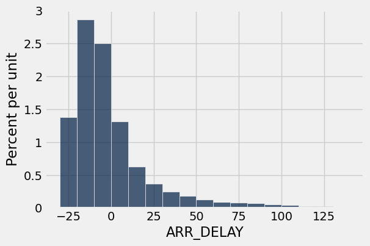

```python
sfo.hist('ARR_DELAY', bins=np.arange(-30, 150, 10))
```

```python
delays = sfo.column('ARR_DELAY')
delay_mean = np.mean(delays)
delay_sd = np.std(delays)
delay_mean, delay_sd
```

```
(1.0869565217391304, 51.865781862374682)
```

Create a function that obtains a sample of a certain size `sample_size` from the `sfo` data and calculates the sample mean.

```python
def one_sample_mean(sample_size):
    """ Takes a sample from the population of flights and computes its mean"""
    sampled_flights = sfo.sample(sample_size)
    return np.mean(sampled_flights.column('ARR_DELAY'))
```

```python
# run this several times to see the variation

one_sample_mean(100)
```

```
-1.29
```

Define a function that replicates 1,000 times getting random samples of a certain size, `sample_size`, from the `sfo` data and calculating the sample mean for each sample.

```python
def ten_thousand_sample_means(sample_size):
    means = make_array()
    for i in np.arange(1000):
        mean = one_sample_mean(sample_size)
        means = np.append(means, mean)
    return means
```

Explore the distribution of sample flight delay means for various sample sizes.

```
Population Average: 1.08695652174
```

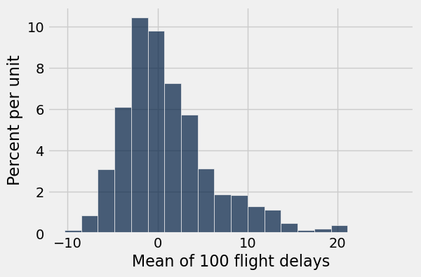

```python
sample_means_100 = ten_thousand_sample_means(100)
Table().with_column('Mean of 100 flight delays', sample_means_100).hist(bins=20)
print('Population Average:', delay_mean)
```

```
Population Average: 1.08695652174
```

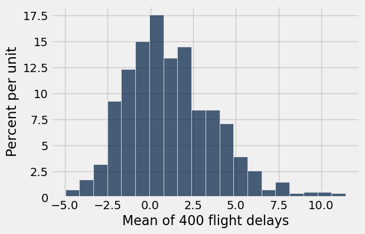

```python
# above is slightly right skewed, center is just above 0

sample_means_400 = ten_thousand_sample_means(400)
Table().with_column('Mean of 400 flight delays', sample_means_400).hist(bins=20)
print('Population Average:', delay_mean)
```

```
Population Average: 1.08695652174
```

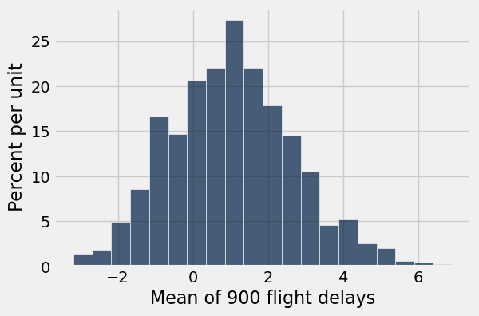

```python
# Above is more normal, spread is smaller, height is taller than for n=100

sample_means_900 = ten_thousand_sample_means(900)
Table().with_column('Mean of 900 flight delays', sample_means_900).hist(bins=20)
print('Population Average:', delay_mean)
```